# Exploratory Data Analysis

Analysis of SIHSUS data on State of Pernambuco, Brazil

João Miguel Alves, Rafaela Leal Silva, Rita Amorim

31/10/2020

## Introduction

The purpose of this report is to provide an Exploratory Data Analysis (EDA) on data collected from SIHSUS - Brazilian Hospital Information System. Data from Pernambuco state between 2014 and 2016 was accessed.

## Data Setup

### Data Download and Conversion

For this project we have used data from the Brazilian Hospital Information System (SIHSUS). Data from Pernambuco state was retrieved from ftp.datasus.gov.br from years 2014 to 2016.

As files are only available in DBC filetype, we did a conversion to CSV files for convenience of use. Here below the code used to this process:

```r
setwd("C:/HEADS/DATA/DBC_files")

#--------------------------------------------------------------
# Download .dbc files from URL
#--------------------------------------------------------------
library(RCurl)
url = "ftp://ftp.datasus.gov.br/DISSEMIN/publicos/SIHSUS/MHJ_14_16/"
filenames = getURL(url, ftp.use.epsv = FALSE, dirlistonly = TRUE)
filenames <- strsplit(filenames, "\r\n")
filenames = unlist(filenames)
for (filename in filenames) {
  if( grepl("RDPE", filename)){ #PE for Pernambuco state
    download.file(paste(url, filename, sep = ""),
                  paste(getwd(), "/", filename, sep = ""), mode="wb")
  }
}

#--------------------------------------------------------------
# Convert .dbc files to .csv
#--------------------------------------------------------------
library(read.dbc)
setwd("C:/HEADS/DATA/DBC_files")
filenames  = list.files()
outputdir <- "C:/HEADS/DATA/CSV_files"

for (filename in filenames) {
  x <- read.dbc(filename)
  file = substr(filename, 1, 8)
  url = paste(outputdir, paste(file, "csv", sep = "."), sep = "/")
  write.csv(x, file = url)
}
```

### Loading data in memory

As our download retrieved 36 files (12 months * 3 years), we opted to load data in memory using package `plyr` for a 1-step action.

```r
setwd("C:/HEADS/DATA/CSV_files")
dataset <- ldply(list.files(), read.csv, header = TRUE)
dim(dataset)
```

```
## [1] 1635485     114
```

Our data set was comprised of 1635485 observations referring to the years 2014 to 2016. A simple cross table on months and years yields the following frequencies:

```r
table(dataset$ANO_CMPT, dataset$MES_CMPT)
```

```
##
##            1     2     3     4     5     6     7     8     9    10    11    12
##   2014 42598 42608 43123 45467 47734 46470 47183 47638 48923 48180 47033 44171
##   2015 44063 41482 46610 46490 47260 46805 45755 46450 44514 44387 44685 42656
##   2016 43928 42944 45795 45223 46872 46221 47300 48002 46759 44988 42497 42671
```

The same result can be presented with `formattable()` for improved aesthetics:

```r
periods <- as.data.frame.matrix(table(dataset$ANO_CMPT, dataset$MES_CMPT))
formattable(periods, list(area(col = as.character(1:12)) ~ normalize_bar("lightblue", 0.4)))
```

|  | 1 | 2 | 3 | 4 | 5 | 6 | 7 | 8 | 9 | 10 | 11 | 12 |
| --- | --- | --- | --- | --- | --- | --- | --- | --- | --- | --- | --- | --- |
| 2014 | 42598 | 42608 | 43123 | 45467 | 47734 | 46470 | 47183 | 47638 | 48923 | 48180 | 47033 | 44171 |
| 2015 | 44063 | 41482 | 46610 | 46490 | 47260 | 46805 | 45755 | 46450 | 44514 | 44387 | 44685 | 42656 |
| 2016 | 43928 | 42944 | 45795 | 45223 | 46872 | 46221 | 47300 | 48002 | 46759 | 44988 | 42497 | 42671 |

From function `dim()` we can observe that our data set was comprised of 114 variables. Having consulted the variables dictionary, we have opted to discard any variables for which no description was provided, as well as any variables carrying meaningless data for our analysis. Variables constituted uniquely by NA values were also discarded. For this step we have used `dplyr` package.

```r
#--------------------------------------------------------------
# Redefine dataset only with meaningful variables
#--------------------------------------------------------------
dataset <- dplyr::select(dataset, X, UF_ZI, ANO_CMPT, MES_CMPT, ESPEC, CGC_HOSP,
                         N_AIH, IDENT, CEP, MUNIC_RES, NASC, SEXO, MARCA_UTI,
                         UTI_INT_TO, DIAR_ACOM, QT_DIARIAS, DT_INTER, DT_SAIDA,
                         DIAG_PRINC, DIAG_SECUN, COBRANCA, NAT_JUR, GESTAO,
                         IND_VDRL, MUNIC_MOV, COD_IDADE, IDADE, DIAS_PERM,
                         MORTE, NACIONAL, CAR_INT, HOMONIMO, NUM_FILHOS,
                         INSTRU, CONTRACEP1, CONTRACEP2, GESTRISCO,
                         CID_ASSO, CID_MORTE, RACA_COR, ETNIA, AUD_JUST,
                         SIS_JUST, MARCA_UCI, DIAGSEC1, DIAGSEC2, DIAGSEC3,
                         DIAGSEC4, DIAGSEC5, DIAGSEC6, DIAGSEC7, TPDISEC1,
                         TPDISEC2, TPDISEC3, TPDISEC4, TPDISEC5, TPDISEC6,
                         TPDISEC7)
```

This process trimmed down our data set from 114 to 58 meaningful variables.

As a next step, we have identified categorical and numerical variables, and redefined them accordingly as `factor` or as `integer`. Text variables automatically identified as `character` were left unchanged.

```r
#--------------------------------------------------------------
# Identify columns to be AS.FACTOR
#--------------------------------------------------------------
cols.fact <- c("UF_ZI", "ANO_CMPT", "MES_CMPT", "ESPEC", "CGC_HOSP", "N_AIH",
               "IDENT", "CEP", "MUNIC_RES", "SEXO", "MARCA_UTI", "DIAG_PRINC",
               "DIAG_SECUN", "COBRANCA", "NAT_JUR", "GESTAO", "IND_VDRL",
               "MUNIC_MOV", "COD_IDADE", "MORTE", "NACIONAL", "CAR_INT",
               "HOMONIMO", "INSTRU", "CONTRACEP1", "CONTRACEP2", "GESTRISCO",
               "CID_ASSO", "CID_MORTE", "RACA_COR", "ETNIA", "MARCA_UCI",
               "DIAGSEC1", "DIAGSEC2", "DIAGSEC3", "DIAGSEC4", "DIAGSEC5",
               "DIAGSEC6", "DIAGSEC7", "TPDISEC1", "TPDISEC2", "TPDISEC3",
               "TPDISEC4", "TPDISEC5", "TPDISEC6", "TPDISEC7" )

#--------------------------------------------------------------
# Identify columns to be AS.INTEGER
#--------------------------------------------------------------
cols.integ <- c( "UTI_INT_TO", "DIAR_ACOM", "QT_DIARIAS", "IDADE", "DIAS_PERM",
                 "NUM_FILHOS", "NASC", "DT_INTER", "DT_SAIDA" )

#--------------------------------------------------------------
# Apply change of variable type
#--------------------------------------------------------------
dataset[cols.fact] <- lapply(dataset[cols.fact], as.factor)
dataset[cols.integ] <- lapply(dataset[cols.integ], as.integer)
```

After this change, data set structure results as follows:

```r
str(dataset)
```

```
## 'data.frame':    1635485 obs. of  58 variables:
##  $ X         : int  1 2 3 4 5 6 7 8 9 10 ...
##  $ UF_ZI     : Factor w/ 160 levels "260000","260005",..: 1 1 1 1 1 1 1 1 1 1 ...
##  $ ANO_CMPT  : Factor w/ 3 levels "2014","2015",..: 1 1 1 1 1 1 1 1 1 1 ...
##  $ MES_CMPT  : Factor w/ 12 levels "1","2","3","4",..: 1 1 1 1 1 1 1 1 1 1 ...
##  $ ESPEC     : Factor w/ 11 levels "1","2","3","4",..: 4 4 4 4 4 4 7 7 7 7 ...
##  $ CGC_HOSP  : Factor w/ 109 levels "523053000197",..: 69 69 69 69 69 69 69 69 69 69 ...
##  $ N_AIH     : Factor w/ 1609363 levels "2608100288761",..: 118789 118790 118791 118792 118846 118909 116370 116371 116372 116373 ...
##  $ IDENT     : Factor w/ 2 levels "1","5": 1 1 1 1 1 1 1 1 1 1 ...
##  $ CEP       : Factor w/ 43649 levels "1001000","1001010",..: 14364 7912 16932 34877 26668 21579 36874 32752 18795 34842 ...
##  $ MUNIC_RES : Factor w/ 1604 levels "110002","110003",..: 691 712 702 695 611 668 683 625 581 589 ...
##  $ NASC      : int  19550503 19370326 19560319 19670727 19450223 19330316 20100621 20100319 20100522 20020402 ...
##  $ SEXO      : Factor w/ 2 levels "1","3": 2 1 1 2 2 2 1 2 1 2 ...
##  $ MARCA_UTI : Factor w/ 10 levels "0","1","75","76",..: 1 1 1 1 1 1 1 1 1 1 ...
##  $ UTI_INT_TO: int  0 0 0 0 0 0 0 0 0 0 ...
```

[output cut: 44 more lines]

## Data Screening

As next step, we aimed to detect and address existing data quality issues, especially:

- Incomplete data;
- Outliers;
- Inconsistent data;
- Unreliable data;
- Improperly formatted/structured data.

Each of these topics will be addressed in the subsequent subsections.

### Incomplete data

Incomplete data, also called missing values, refers to fragments of non-existing information.

We applied the following script to identify variables with missing values:

```r
na.vars <- data.frame(sapply(dataset, function(x) sum(is.na (x))))
colnames(na.vars) <- c("MissingValues")
subset(na.vars, na.vars != 0)
```

|  | MissingValues |
| --- | --- |
| CGC_HOSP | 425893 |
| DIAG_SECUN | 467071 |
| CID_ASSO | 549570 |
| CID_MORTE | 529556 |
| AUD_JUST | 1626404 |
| SIS_JUST | 1626405 |
| DIAGSEC1 | 1448209 |
| DIAGSEC2 | 1616529 |
| DIAGSEC3 | 1627973 |
| DIAGSEC4 | 1632154 |

[output cut: 10 more lines]

Nevertheless, it did not result clear to us why `CGC_HOSP` referring to Hospital ID exhibits null values in a significant number of observations, which we consider as incomplete data.

### Outliers

#### Number of Children

On this parameter, we’ve noticed that most observations gather around 0, with some outliers reporting >20 children, as shown below:

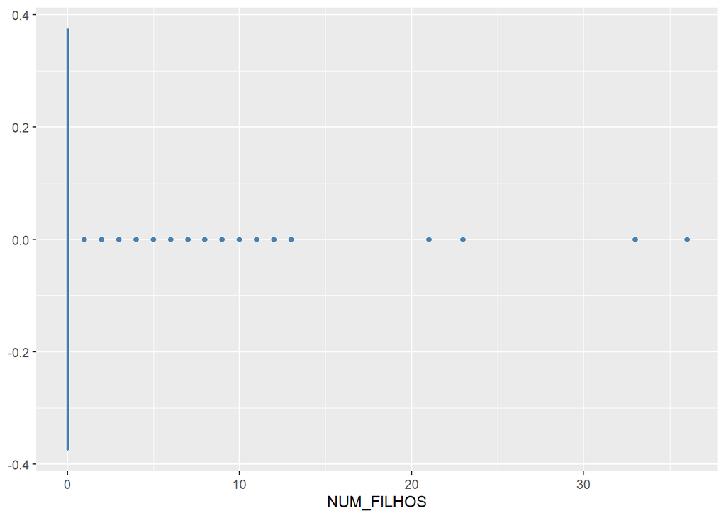

```r
ggplot(data = dataset, aes(x = NUM_FILHOS)) +
  geom_boxplot(color = "steelblue")
```

In order to understand if these are artificial outliers an analysis of number of children per sex was done. Individuals with more than 20 children were Man, which is possible and makes us believe that these are real outliers.

```r
child <- dataset %>% filter(COD_IDADE == "4", NUM_FILHOS > 0) %>% select(SEXO, NUM_FILHOS)
levels(child$SEXO) <- c("Male", "Female")
child.per.sex <- as.data.frame.matrix(table(child$SEXO, child$NUM_FILHOS))
child.per.sex[child.per.sex == 0] <- "-"
formattable(child.per.sex, list(area (col = names(child.per.sex)) ~ color_tile("darkseagreen1", "darkslategray1")))
```

|  | 1 | 2 | 3 | 4 | 5 | 6 | 7 | 8 | 9 | 10 | 11 | 12 | 13 | 21 | 23 | 33 | 36 |
| --- | --- | --- | --- | --- | --- | --- | --- | --- | --- | --- | --- | --- | --- | --- | --- | --- | --- |
| Male | 596 | 2241 | 1209 | 319 | 122 | 50 | 19 | 11 | - | 1 | 1 | 2 | - | 1 | 1 | 1 | 1 |
| Female | 222 | 2623 | 2016 | 814 | 206 | 87 | 48 | 40 | 21 | 5 | 4 | - | 1 | - | - | - | - |

*Cross table showing number of children reported by sex of inpatient*

## Clinical Domain

An aim of this project was to address a specific clinical domain of interest. For this purpose, we analyzed the main diagnosis reported (coded as `DIAG_PRINC`) and plotted the results under a barchart.

The top-10 results indicate a higher frequency of diagnosis from family **O00-O9A - Pregnancy, childbirth and the puerperium**, as exhibited below. We focused our analysis on Obstetrics ICD-10 codes family, as this is the most frequent among main diagnostics reported.

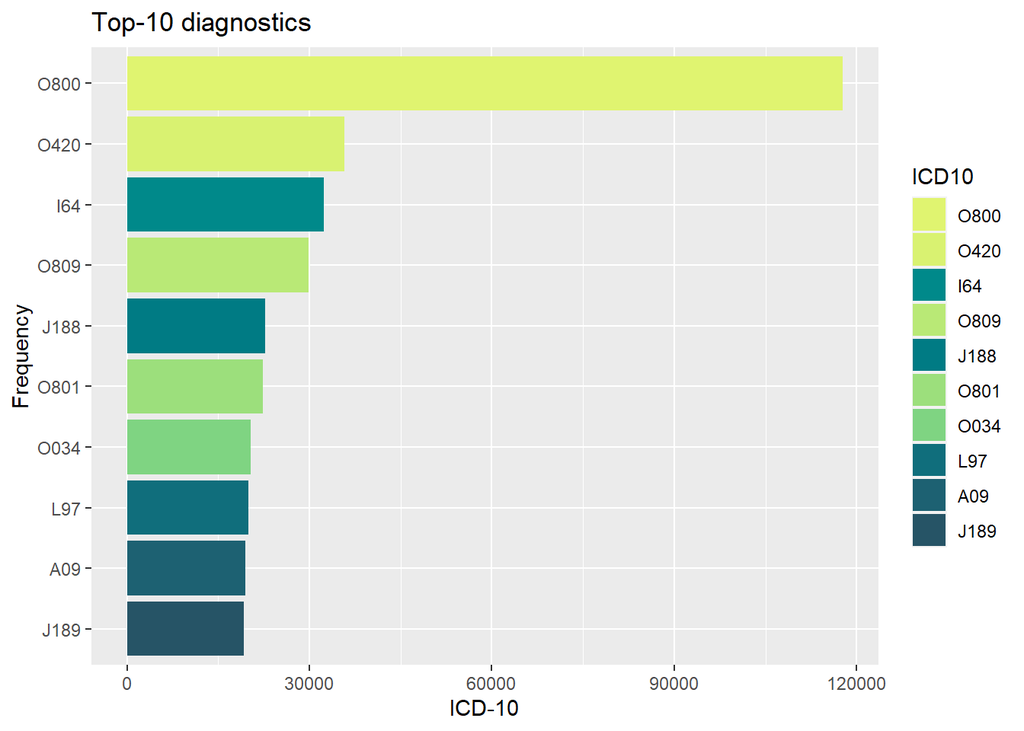

| ICD-10 | Description |
| --- | --- |
| O80.0 | Spontaneous vertex delivery |
| O42.0 | Premature rupture of membranes, onset of labour within 24 hours |
| I64 | Stroke, not specified as haemorrhage or infarction |
| O80.9 | Single spontaneous delivery, unspecified |
| J18.8 | Other pneumonia, organism unspecified |
| O80.1 | Spontaneous breech delivery |
| O03.4 | Spontaneous abortion : incomplete, without complication |
| L97 | Ulcer of lower limb, not elsewhere classified |
| A09 | Other gastroenteritis and colitis of infectious and unspecified origin |
| J18.9 | Pneumonia, unspecified |

```r
diagnosis.main <- data.frame(sort(table(dataset[,"DIAG_PRINC"]), decreasing = TRUE)[1:10])
colnames(diagnosis.main) <- c("ICD10", "Freq")
ggplot(diagnosis.main, aes(x = fct_rev(ICD10), y = Freq, fill = ICD10)) +
  geom_bar(stat = "identity") +
  coord_flip() +
  labs(x = "Frequency", y = "ICD-10", title = "Top-10 diagnostics") +
  scale_fill_manual(values=c("#e0f470", "#d9f271",  "#00898a", "#b9e976", "#007b84",
                             "#9cdf7c", "#7fd482", "#106e7c", "#1d6172",  "#265466"))
```

*Top-10 diagnosis reported.*

### Improperly structured data

On this section, we looked at data that might be improperly formatted. For this purpose, we have analyzed 2 data variables referring to admission date and discharge date (`DT_INTER` and `DT_SAIDA`, respectively). Both these variables were registered as 8-characters long strings, structured as YYYYMMDD.

We have converted both variables into date format. Consecutively, we have computed the difference between both values, as to calculate length of stay as a new variable `DIAS_CALC`.

This analysis uses package `lubridate`. No improperly structured data was found on these fields. However, the maximum value for the length of stay reveals an unexpected value of 3287 days, much longer than the 3 years range on our dataset.

```r
dataset$DATA_SAIDA <- as.Date(as.character(dataset$DT_SAIDA), format = "%Y%m%d")
dataset$DATA_INTER <- as.Date(as.character(dataset$DT_INTER), format = "%Y%m%d")
dataset$DIAS_CALC <- as.numeric(difftime(dataset$DATA_SAIDA, dataset$DATA_INTER), units = "days")
summary(dataset$DIAS_CALC)
```

```
##    Min. 1st Qu.  Median    Mean 3rd Qu.    Max.
##    0.00    2.00    3.00   17.33    6.00 3287.00
```

### Unreliable data

On the search for unreliable data, we have filtered our dataset for Obstetrics observations as main diagnosis (`DIAG_PRINC`).

In this setting, we observe that the median length of stay lays at 2 days, with an IRQ of 2 days (i.e, 1 to 3 days). This data is consistent with standard practice. However, a brief look at `summary` reveals a a maximum of 336 days as length of stay, which is not plausible for common Obstetrics practice.

```r
obst <- dplyr::filter(dataset, grepl("O",DIAG_PRINC))
obst$DIAG_PRINC <- droplevels(obst$DIAG_PRINC)
summary(obst$DIAS_CALC)
```

```
##    Min. 1st Qu.  Median    Mean 3rd Qu.    Max.
##    0.00    1.00    2.00    2.63    3.00  336.00
```

A boxplot serves to illustrate these results more clearly:

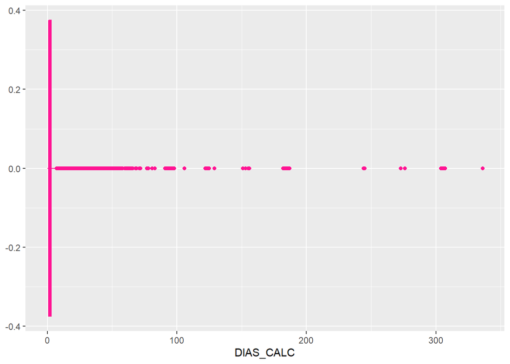

```r
ggplot(data = obst, aes(x = DIAS_CALC)) +  geom_boxplot(color = "deeppink")
```

### Inconsistent data

Still on Obstetrics observations, we searched for inconsistent date regarding sex of inpatients. A simple table reveals that only women are reported with Obstetrics diagnosis, as expected.

```r
levels(obst$SEXO) <- c("male", "female")
table(obst$SEXO)
```

```
##
##   male female
##      0 370083
```

However, an analysis on age of inpatients reveals data that should not occur, such as patients age below six years and above eighty years.

```r
obst$COD_IDADE <- droplevels(obst$COD_IDADE)
levels(obst$COD_IDADE) <- c("Months", "Days", "Years")
#Cut age range into groups
obst$IDADE_GRUPO <- cut(obst$IDADE, breaks = c(0,6,12,18,24,30,40,50,65,80,Inf))
#Set crosstable as data.frame
obst.ages <- as.data.frame.matrix(table(obst$COD_IDADE, obst$IDADE_GRUPO))
obst.ages[obst.ages == 0] <- NA
#Plot crosstable with formattable
formattable(obst.ages, list(area(col = 1:10) ~ color_tile("orange", "chartreuse")))
```

|  | (0,6] | (6,12] | (12,18] | (18,24] | (24,30] | (30,40] | (40,50] | (50,65] | (65,80] | (80,Inf] |
| --- | --- | --- | --- | --- | --- | --- | --- | --- | --- | --- |
| Months | 10 | NA | 1 | NA | NA | NA | NA | NA | NA | NA |
| Days | 1 | 1 | NA | NA | NA | NA | NA | NA | NA | NA |
| Years | 10 | 145 | 68986 | 128956 | 95689 | 70121 | 5940 | 144 | 44 | 22 |

#### Causes of Death in Obstetrics

From the 84 deaths in Obstetrics we noticed that only 19 reported a cause of death `CID-MORTE`, from which 5 don’t belong to Obstetrics related ICD-10 codes. By comparing the causes of death `CID_MORTE` with the principal diagnosis `DIAG_PRINC` we noticed that the majority of the `CID_MORTE` codes were the same as `DIAG_PRINC` code, as illustrated below:

```r
## filter by Obstetrics service (ESPEC=2) and death reports (morte=0, cod_morte!=0)
obst.death <- dataset %>% filter(ESPEC == 2, MORTE == 1, CID_MORTE != 0) %>%
  select(CID_MORTE, DIAG_PRINC) %>% arrange(CID_MORTE)
obst.death$CID_MORTE <- droplevels(obst.death$CID_MORTE)
obst.death$DIAG_PRINC <- droplevels(obst.death$DIAG_PRINC)
obst.death.table <- as.data.frame.matrix(table(obst.death$CID_MORTE, obst.death$DIAG_PRINC))

obst.death.table$Count <- rowSums(obst.death.table)     ##adds count column
obst.death.table$Description <- c(          ##add column with ICD10 descriptions
  "Pulmonary oedema",
  "Hepatic failure, unspecified",
  "Essential hypertension pregnancy",
  "Secondary hypertension pregnancy",
  "Gestational hypertension",
  "Unspecified maternal hypertension",
  "Premature rupture of membranes (24h)",
  "Premature rupture of membranes (>24h)",
  "Spontaneous vertex delivery",
  "Obstetric death of unspecified cause",
  "Cardiogenic shock",
  "Hypovolaemic shock",
  "Infection following immunization"
)

obst.death.table[obst.death.table == 0] <- "" #remove 0 for better reading
formattable(obst.death.table, align = c(rep("c", 13), "r", "l"),
            list(area(col = Count) ~ normalize_bar("lightcoral", 0.2)
                 ))
```

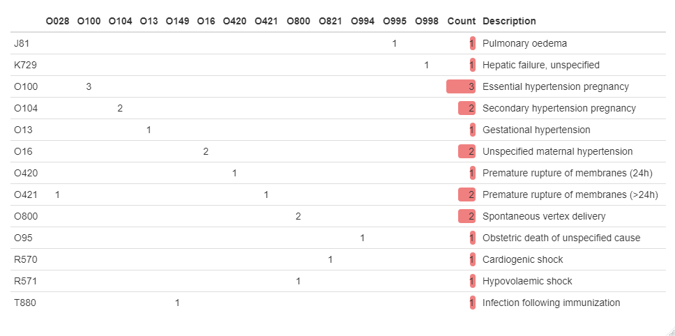

*Cross table showing ICD-10 codes for cause of death `CID_MORTE` as rows, against ICD-10 codes for main diagnosis `DIAG_PRINC` reported in Obstetrics service (n=19)*

According to WHO, the major complications that account for nearly 75% of all maternal deaths are severe bleeding, infections, high blood pressure during pregnancy, complications from deliver and unsafe abortion. In our analysis from Pernambuco state the top 10 causes are in agreement with WHO data. In the previous table we see cardiogenic/hypovolemic shock as causes of death, which can be the consequence of severe bleeding. Infection could be related with immunization as seen in our data and also with premature rupture of membranes. There are also different conditions related to hypertension shown. In our opinion, “spontaneous vertex delivery” should not be considered as a cause of death, so we consider that misclassification may have occurred.

## Conclusion

The use of big data in healthcare has the potential to represent the real world, make the connection between several datasets, innovate and improve systems-level understanding. However, with this work, we faced real problems and limitations associated with big data analysis.

To draw conclusions with an impact on clinical practice, data analysis has to be done with caution and create information that is accurate and reliable. In order to improve data quality, data management should be mandatory in health sciences.